**Contributors:**  
**Amit Kumar Singh (amitksingh@iisc.ac.in)**  
**Vaibhav Bansal (bvaibhav@iisc.ac.in)**

# Non-linear least square problems

## Introduction

Artificial Intelligence is transforming the world at a great pace, so it motivates many people to learn the fundamentals of these trending technologies. This blog on **methods for solving non-linear least square problems** will help you understand the math behind non-linear problem analysis and how to solve real-world problem as non-linear least square problem. Also, we will discuss some iterative methods to solve it.

The most common example of least squares is the Linear Regression Analysis. It is a mathematical method used to find the best fit line that represents the relationship between an independent and dependent variable. Non-linear least squares regression extends linear least squares regression for use with a much larger and more general class of functions. Almost any function that can be written in closed form can be incorporated into a non-linear regression model.

Advances in computing power, in addition to new financial engineering techniques have increased the use of least square methods and extended its basic principles. The least squares criterion method is used throughout finance, economics, and investing. It is used to estimate the accuracy of a line depicting the data that was used to create it. Least squares results can also be used to summarize data and make predictions about related but unobserved values from the same group or system.

While the method of least squares often gives optimal estimates of the unknown parameters, it is very sensitive to the presence of unusual data points in the data used to fit a model. One or two outliers can sometimes seriously skew the results of a least squares analysis. This makes model validation, especially with respect to outliers, critical to obtaining sound answers to the questions motivating the construction of the model. It is also really hard to generalize least square methods for multi-class classification problem.

In the following blog, iterative methods are described to solve problems of non-linear least squares. These methods differ according to whether they evaluate Hessians, gradients, or only function values. While evaluating Hessians (H) and gradients (G) improves the rate of convergence, for functions for which these quantities exist and vary sufficiently smoothly, such evaluations increase the computational complexity (or computational cost) of each iteration. In some cases, the computational complexity may be excessively high. This is a classic optimization problem. Let's understand the concept of optimization.

**Optimization** is the selection of the best element (with regard to some criterion) from some set of available alternatives. In the simplest case, an optimization problem consists of maximizing or minimizing a real function by systematically choosing input values from within an allowed set and computing the value of the function. To solve problems, researchers may use algorithms that terminate in a finite number of steps, or iterative methods that converge to a solution (on some specified class of problems), or heuristics that may provide approximate solutions to some problems (although their iterates need not converge). Optimization techniques have become increasingly important and popular in different engineering applications like:

1. **Inventory control**: Inventory control is the process of keeping the right number of parts and products in stock to avoid shortages, overstocks or excess inventory, or any other thing that incurs a huge cost.
2. **Scheduling**: Scheduling in a computer is the process of distributing computing resources like processor time, bandwidth, and memory to various processes, threads, and data flow, and all the running applications.
3. **Machine learning**: The principal goal of machine learning is to create a model that performs well and gives accurate predictions in a particular set of cases. We adjust hyperparameters in order to minimize the cost function by using one of the optimization techniques.

Iterative approaches used by optimization techniques are sensitive to the starting point. In some cases, the conditions on the function that are necessary for convergence are satisfied, but the point chosen as the initial point is not in the interval where the method converges. Finding the best starting point is an open research problem.

With this background, let's study the non-least square problem formally. After completing this blog, you will know:

1. A formal definition of least square problem.
2. Descent method for solving non-linear least square problems. We will cover following methods:  
   A. Gauss-Newton Method  
   B. Levenberg-Marquardt Method  
   C. Powell's Dog Leg Method.
3. Real world problem formulation (Population growth estimation).

## Definitions

### Least square problem

Given a function $f:R^n \longmapsto R^m$ with $m>n$. We want to find $x^* = argmin_x\{F(x)\}$, where \begin{align*} F(x)=\frac{1}{2}\sum_{i=1}^{i=m} f_i(x)^2 = \frac{1}{2}\lvert\lvert f(x) \rvert\rvert^2 = \frac{1} {2}f(x)^Tf(x) \end{align*}

Least square problems can be solved by general optimization methods, but we shall present special methods that are more efficient. In many cases they achieve better than linear convergence, sometimes even quadratic convergence, even though they do not need implementation of second derivatives. In the description of the methods, we shall need formulas for derivatives of $F$: provided that $f$ has continuous second partial derivatives, we can write its Taylor expansion as \begin{align*} f(x+h) &= f(x)+J(x)h+O(\lvert\lvert h \rvert\rvert^2) &\text{where, $J\in R^{mxn}$ is a Jacobian.}\\ F^\prime(x)&=J(x)^Tf(x)\\ F^{\prime\prime}(x)&=J(x)^TJ(x)+ \sum_{i=1}^{i=m}f_i(x)f_i^{\prime\prime}(x) \end{align*}

## Solutions

### Descent Methods

All methods for non-lienar optimization are iterative. From a starting point $x_0$ the method converges to $x^*$, a local minimizer for the given function. Most methods have measure which enforce the descending condition $F(x_{k+1})<F(x_k)$.  
From Taylor expansion, we see that, \begin{align*} F(x+\alpha h)&=F(x)+\alpha h^TF^\prime (x)+O(\alpha^2) \\ &\simeq F(x)+\alpha h^TF^\prime (x) \text{, for small } \alpha \\ \end{align*} $h$ is descent direction for $F$ at $x$ if $h^TF^\prime (x)<0$. If no $h$ exists, then $F^\prime (x)=0$, showing that $x$ is stationary.  
Methods presented here are descent methods which satisfy descending condition in each step of iteration. One step from the current iterate consists in

- Find a descent direction $h_d$, and
- Find the step length giving food decrease in $F$-value.

Thus the outline of descent method is,

```
begin
    k=0
    x=x0
    found=False
    while(not found) and (k<k_max):
        hd=searchDirection(x)
        if(no such h exists):
            found=True
        else:
        alpha=stepLength(x,hd)
        x+=alpha*hd
        k+=1
end
```

### Gauss-Newton Method

It is based on the linear approximation of the components of $f$ in the neighborhood of x. In special cases, it can give quadratic convergence.  
For small $||h||$,

\begin{align*} f(x+h) \simeq l(h) & \equiv f(x)+J(x)h \\ F(x+h) \simeq L(h) & \equiv \frac{1}{2}l(h)^Tl(h) \\ &= F(x)+h^TJ^Tf+\frac{1}{2}h^TJ^TJh \\ h_{gn} &= argmin_h{L(h)} &\text{Gauss-Newton step minimizes L(h)}\\ L^{\prime}(h)&=J^Tf+J^TJh &\text{Gradient of } L \\ L^{\prime\prime}(h)&=J^TJ & \text{Hessian of } L \text{, not a function of }h\\ (J^TJ)h_{gn}&=-J^Tf &h_{gn}\text{=minimizer of }L(h)\\ h_{gn}^TF^{\prime}(x) &= h_{gn}^T(J^Tf) = -h_{gn}^T(J^TJ)h_{gn} < 0 &\text{hence, }h_{gn} \text{ is a descent direction of F}\\ \end{align*}

We know that Newton's method for optimization has quadratic convergence. This usually is not the case with the Gauss-Newton method. To see this, we compare the search direction used in two methods, \begin{align*} F^\prime (x+h)& \simeq F^\prime(x)+F^{\prime\prime}(x)h &\text{Taylor's expansion}\\ F^\prime (x^*)&=0 & x^* \text{ is stationary (Newton's method)}\\ F^{\prime\prime}(x)h_n &= -F^{\prime}(x) &\text{search direction for Newton's method}\\ L^{\prime\prime}(h)h_{gn} &= -L^{\prime}(0) &\text{search direction for Gauss-Newton method}\\ F^{\prime\prime}(x)&=L^{\prime\prime}(x)+ \sum_{i=1}^{i=m}f_i(x)f_i^{\prime\prime}(x) & \text{because } F^{\prime}(x)=L^{\prime}(0)\\ \end{align*} If $f(x^*)=0$, then $L^{\prime\prime}(x)h=F^{\prime\prime}(x)$ for $x$ close to $x^*$, and we get quardratic convergence also with the Gauss Newton method. We can expect super-linear convergence if the function $\{f_i\}$ have small curvatures or if $\{|f_i()x|\}$ are small, but in general we must expect linear convergence.

Let's go through the example for a better understanding of the non-linear least squares

### Example 1

\begin{align*} f(x)&= \begin{bmatrix} x+1\\ \lambda x^2+x-1 \end{bmatrix}\\ F(x) &= \frac{1}{2}(x+1)^2+\frac{1}{2}(\lambda x^2+x-1)^2\\ \text{it follows that, }\\ F^{\prime}(x)&=2\lambda^2x^3+3\lambda x^2-2(\lambda -1)x \\ F^{\prime\prime}(x)&=6\lambda^2x^2+6\lambda x-2(\lambda-1)\\ J(x)&= \begin{bmatrix} 1\\ 2\lambda x+1 \end{bmatrix}\\ \text{Thus classical Gauss-Newton method from }x_k \text{ gives,}\\ x_{k+1} &= x_k - \frac{2\lambda^2 x_k^3 + 3\lambda x_k^2-2(\lambda-1)x_k}{2+4\lambda x_k + 4\lambda^2x_k^2} \end{align*}

- $|\lambda|<1$ and $|\lambda|\neq 0$, we get solution with linear convergence.
- $\lambda<-1$, then Gauss-Newton method can't find the minimizer.
- $\lambda=0$, then we find the solution in one step. In this case $f$ is linear function.

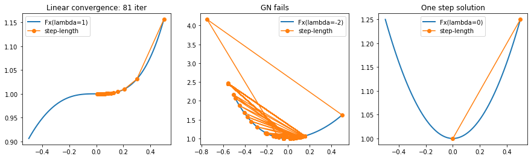

```python
import numpy as np
import matplotlib.pyplot as plt
import sys

tol = 1e-4
def gaussNewton(x, l=1):
    jacob = lambda x: np.asarray([1, 2*l*x+1])
    res = lambda x: np.asarray([x+1, l*x**2+x-1])
    x_hist = []
    x_hist.append(x)
    for k in range(1000):
        h_gn = -(jacob(x).T@res(x))/(jacob(x).T@jacob(x))
        if(abs(h_gn) < tol):
            x_hist = np.asarray(x_hist)
            return x_hist
        x+=h_gn
        x_hist.append(x)
    x_hist = np.asarray(x_hist)
    return x_hist

def Fx(x,l=1):
    F = np.square(x+1) + np.square(l*np.square(x)+x-1)
    return 0.5*F

l_list = [1, -2, 0]
x0=0.5
x_hist_c1 = gaussNewton(x=x0,l=l_list[0])
x_hist_c2 = gaussNewton(x=x0,l=l_list[1])
x_hist_c3 = gaussNewton(x=x0,l=l_list[2])

# visualize function
fig,ax = plt.subplots(1,3,figsize=(15,4))
x = np.linspace(-0.5, 0.5, 100)

ax[0].plot(x, Fx(x,l=l_list[0]), label='Fx(lambda='+str(l_list[0])+')', linewidth=2)
ax[0].plot(x_hist_c1, Fx(x_hist_c1, l=l_list[0]), '-o', label='step-length'),
ax[0].legend(), ax[0].set_title('Linear convergence: '+str(len(x_hist_c1))+' iter')

ax[1].plot(x,Fx(x,l=l_list[1]), label='Fx(lambda='+str(l_list[1])+')', linewidth=2)
ax[1].plot(x_hist_c2,Fx(x_hist_c2, l=l_list[1]),  '-o', label='step-length'),
ax[1].legend(), ax[1].set_title('GN fails')

ax[2].plot(x,Fx(x,l=l_list[2]), label='Fx(lambda='+str(l_list[2])+')', linewidth=2)
ax[2].plot(x_hist_c3,Fx(x_hist_c3, l=l_list[2]), '-o', label='step-length'),
ax[2].legend(), ax[2].set_title('One step solution')

plt.show()
```

The above example shows that the Gauss-Newton method may fail. However, in many applications, it gives a quite good performance, though it normally only has linear convergence as opposed to the quadratic convergence from Newton's method with implemented second derivatives.  
Next, we will present a method with superior global performance.

### Levenberg-Marquardt Method

Levenberg and Marquardt suggested using a damped Gauss-Newton method. The step $h_{lm}$ is defined by the following modification to Gauss-Newton method, \begin{align*} (J^TJ+\mu I)h_{lm} = -J^Tf \text{ with } \mu>0 \end{align*} The damping factor $\mu$ has several effects:

- For all $\mu$>0, the cofficient matrix is positive definite, and this ensures that $h_{lm}$ is a descent direction.
- For large values of $\mu$, we get $h_{lm} \simeq -\frac{1}{\mu}J^Tf = -\frac{1}{\mu}F^{\prime}(x)$, ie a short step in the steepest descent direction. This is good if current current iterate is far from the solution.
- If $\mu$ is very small, then $h_{lm} \simeq h_{gn}$, which is a good step in the final stages of the iteration, when $x$ is close to $x^*$. We can expect almost quadratic convergence if $F(x^*)=0$.

Thus, the damping parameter influences both the direction and the size of the step length.

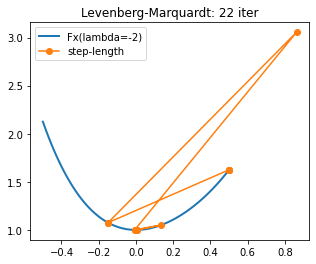

```python
from scipy.optimize import least_squares
import numpy as np
import matplotlib.pyplot as plt

x_hist = []
def Fx(x,l=-2):
    x_hist.append(x[0])
    F = np.square(x+1) + np.square(l*np.square(x)+x-1)
    return 0.5*F
least_squares(Fx, x0=0.5, method='lm', xtol=1e-4)
x_hist = np.asarray(x_hist)

def FxEval(x,l=-2):
    F = np.square(x+1) + np.square(l*np.square(x)+x-1)
    return 0.5*F

x = np.linspace(-0.5, 0.5, 100)
fig,ax = plt.subplots(1,1,figsize=(5,4))
ax.plot(x,FxEval(x,l=-2), label='Fx(lambda='+str(-2)+')', linewidth=2)
ax.plot(x_hist,FxEval(x_hist,l=-2),  '-o', label='step-length'), ax.legend(),
ax.set_title('Levenberg-Marquardt: '+str(len(x_hist))+' iter')
plt.show()
```

The above Figure shows that the Levenberg-Marquardt method is able to find the minima when GN fails (Example 1). The Levenberg-Marquardt method works with combinations of the Gauss-Newton & steepest descent direction. It follows the trust-region strategy, where the radius of a trust region is implicitly controlled by damping parameter $\mu$.  
Next, we will present another similar method, i.e., Powell's Dog Leg Method, where the radius of a trust region is explicitly controlled.

### Powell's Dog Leg Method

We have seen that, at current iterate $x$, \begin{align*} J^TJ h_{gn} &= -J^Tf &\text{ Gauss-Newton step}\\ h_{sd} &= -J^Tf &\text{ Steepest descent direction}\\ f(x+\alpha h_{sd}) &\simeq f(x)+\alpha Jh_{sd} \\ F(x+\alpha h_{sd}) &\simeq \frac{1}{2}||f(x)+\alpha Jh_{sd}||^2 &\text{minimize for $\alpha$.}\\ \alpha &= -\frac{h_{sd}^TJf}{||Jh_{sd}||^2} &\text{optimal step in steepest descent direction.} \end{align*} So we have two candidates for the step to take from current iterate $x$: $a=\alpha h_{sd}$ and $b=h_{gn}$.  
Powell suggested to use the following strategy for choosing the step, when the trust region has radius $\Delta$.

> if $||h_{gn}|| \leq \Delta \rightarrow h_{dl}:=h_{gn}$  
> else if $||\alpha h_{sd}|| \geq \Delta \rightarrow h_{dl} := \frac{\Delta}{||h_{sd}||}h_{sd}$  
> else $h_{dl} := \alpha h_{sd} + \beta (h_{gn}-\alpha h_{sd})$ with $\beta$ chosen such that $||h_{dl}||=\Delta$

To monitor the iteration, we can use gain ratio, $\rho = \frac{F(x)-F(x+h_{dl})}{L(0)-L(h_{dl})}$, where $L$ is a linear model, $L(h) = \frac{1}{2}||f(x)+J(x)h||^2$. We use $\rho$ to control the radius $\Delta$ of the trust region. A large value of $\rho$ indicates that the linear model is good. We can increase $\Delta$ and thereby take longer steps, and they will be closer to the Gauss-Newton direction. If $\rho$ is small then we reduce $\Delta$, implying smaller steps, closer to steepest descent direction.

## Application

### Population growth estimation

Let us consider an example of modeling population growth. We are given data of the form $(t_i,y_i), i=1...m$ and we are interested in a model of the form $y=f(t;x)$. Our goal is to find a $x$, that is useful in predicting $y$ accurately from $t$. It consists of the following steps,

1. **Data Analysis/ Preprocessing**: Do necessary preprocessing with data. It involves creating/dropping columns, scaling etc.
2. **Define model**: We can model population growth as differential equation: $$\frac{dP}{dt} = rP(1-\frac{P}{P_{capacity}})$$ where, $P$ = current population, $r$ = growth rate, $P_{capacity}$ = Maximum carrying capacity. It is non linear in parameter $r$ growth rate.
3. **Define objective**: We can define residual as, $$res = \frac{dP}{dt}-rP(1-\frac{P}{P_{capacity}})$$ Hence, objective function is, $$min_{r\in R}f(r) = ||res||^2$$

First, we visualize the data. The quarterly population is given for 100 years.  
(Note: Given data is synthetic.)

```
Initial Population: 50
Population capacity: 1e6
Growth rate ground truth: 0.3
Raw data (first 5 rows):

    # year     P
0    1.00  66.0
1    1.25  73.0
2    1.50  81.0
3    1.75  81.0
4    2.00  94.0
```

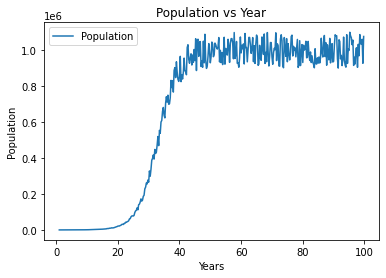

```python
import numpy as np
import math
import matplotlib.pyplot as plt
import random
import sys
import pandas
from scipy.optimize import least_squares

data = pandas.read_csv('population.csv')
print('Initial Population: 50')
print('Population capacity: 1e6')
print('Growth rate ground truth: 0.3')
print("Raw data (first 5 rows): \n\n", data.head())
print('\n')

plt.plot(data['# year'].values, data['P'].values, label='Population')
plt.xlabel('Years')
plt.ylabel('Population')
plt.title('Population vs Year')
plt.legend()
plt.show()
```

We will compute $dP$ and define objective function in code as follows:

```
data['dP'] = data.diff()
data['dP'] = data['dP'].shift(-1)
data.dropna(inplace=True)
def objectiveFunction(x):
    return data['dP'].values - x*data['P'].values*(1-(data['P'].values/capacity))
```

Now minimize objective function using optimization methods defined in previous section. We start $1.0$ as the initial guess of growth rate $r$.

```python
data = pandas.read_csv('population.csv', index_col=0)
data['dP'] = data.diff()
data['dP'] = data['dP'].shift(-1)
data.dropna(inplace=True)

x0 = 1.0
capacity = 1e6
def Fx(x):
    return data['dP'].values - x*data['P'].values*(1-(data['P'].values/capacity))
r_estimated = least_squares(Fx, x0=x0).x[0]
print('r_estimated at convergence is %0.4f'%(r_estimated))
```

```
r_estimated at convergence is 0.3246
```

We hope that our blog on the **non-linear least squares** problem gave you a very insightful explanation. Thanks for reading the blog.